# Closeness & Betweenness Centrality/Centralization in R Lab

CRJ 605 Statistical Analysis of Networks

*This lab examines closeness centrality and betweenness centrality/centralization using the `closeness()`, `betweenness()`, and `centralization()` functions in the `sna` package.*

### **Closeness Centrality (Undirected Binary Graphs)**

How *close* is a node to other nodes? In an undirected binary graph, **closeness centrality** measures how near a node is to the other nodes in the network. This is based on the inverse of the distance of each actor to every other actor.  
Terminology:

- A **geodesic** is the shortest path between two nodes.
- The **distance**, $d(n_i,n_j)$, is the length of the path between *i* and *j*.

Closeness centrality is calculated as: $C_C(n_i) = [\sum\limits_{j=1}^g d(n_i,n_j)]^{-1}$ or $\frac{1}{[\sum\limits_{j=1}^g d(n_i,n_j)]}$.

As can be seen by the equation, we want to first identify the distances between *i* and *j*, sum them, and then take the inverse. We can manually calculate the distance matrix using the `geodist()` function in `sna`.

Let’s take a look:

```r
# First, clear the workspace.
rm(list = ls())

# then, load the sna library.
library(sna)

#now, take a look at the geodist() function.
?geodist
```

Let’s go ahead and set up a simple matrix and examine the geodesics for that matrix.

```r
u.mat <- rbind(c(0,1,0,0,0),c(1,0,1,0,0),c(0,1,0,1,1),c(0,0,1,0,1),c(0,0,1,1,0))
rownames(u.mat) <- c("Jen","Tom","Bob","Leaf","Jim")
colnames(u.mat) <- c("Jen","Tom","Bob","Leaf","Jim")

# let's look at what the geodist() function creates.
u.mat.geodist <- geodist(u.mat)
u.mat.geodist
```

```
## $counts
##      [,1] [,2] [,3] [,4] [,5]
## [1,]    1    1    1    1    1
## [2,]    1    1    1    1    1
## [3,]    1    1    1    1    1
## [4,]    1    1    1    1    1
## [5,]    1    1    1    1    1
##
## $gdist
##      [,1] [,2] [,3] [,4] [,5]
## [1,]    0    1    2    3    3
## [2,]    1    0    1    2    2
## [3,]    2    1    0    1    1
## [4,]    3    2    1    0    1
## [5,]    3    2    1    1    0
```

We can see that the function creates an object of class `list`. In the object, there are two arrays, `$counts` and `$gdist`. To get geodesic distances, we use the `$` sign to select a single piece from the list:

```r
# print out the distances.
u.mat.geodist$gdist
```

```
##      [,1] [,2] [,3] [,4] [,5]
## [1,]    0    1    2    3    3
## [2,]    1    0    1    2    2
## [3,]    2    1    0    1    1
## [4,]    3    2    1    0    1
## [5,]    3    2    1    1    0
```

```r
# If we take the row sum of this object, we get the distances.
rowSums(u.mat.geodist$gdist)
```

```
## [1] 9 6 5 7 7
```

```r
# now, we can create the closeness centrality based on the reciprocal of the row sum.
close.cent <- 1 / rowSums(u.mat.geodist$gdist)
close.cent
```

```
## [1] 0.1111111 0.1666667 0.2000000 0.1428571 0.1428571
```

```r
# We can then calculate the standardized closeness centrality by multiplying by g-1.
g <- dim(u.mat)[1]
close.cent.s <- (g-1) * close.cent
```

Alternatively, we could just use the `closeness()` function in the `sna` package. First, take a look at the function using `?closeness`. Note that the standardized closeness centrality is reported by default. If we want the unstandardized closeness, we can just divide the result returned by `closeness()` by *g-1*.

```r
?closeness
closeness(u.mat,gmode="graph") #standardized.
```

```
## [1] 0.4444444 0.6666667 0.8000000 0.5714286 0.5714286
```

```r
closeness(u.mat,gmode="graph") / (g-1) #raw.
```

```
## [1] 0.1111111 0.1666667 0.2000000 0.1428571 0.1428571
```

#### **Closeness Centralization**

We can also summarize the entire network, in terms of how close nodes are to each other. *Group closeness centralization* tells us how much variation there is in the closeness scores. As with degree centrality, this measure is bound between 0 and 1 where a value of 0 indicates complete uniformity across nodes in there centralization scores and a value of 1 indicates that one node has the highest possible centrality score, and all others are at the minimum.

This is calculated as: $C_C = \frac{\sum\limits_{i=1}^g[C'_C(n^*)-C'_C(n_i)]}{[(g-2)(g-1)]/(2g-3)}$.

Where $C'_C(n^*)$ is the maximum or largest standarized closeness centrality score. For a more elaborate discussion of this equation, see Wasserman & Faust (1994: 191-192). To calculate the group closeness centrality, we can use the `centralization()` function in `sna` and specify `closeness` in the `FUN` argument.

```r
?centralization
centralization(u.mat,closeness,mode="graph")
```

```
## [1] 0.5518519
```

### **Betweenness Centrality (Undirected Binary Graphs)**

We have seen how centrality can be conceptualized as having a high number of ties (i.e. degree centrality) or being close to others in the network (i.e. closeness centrality). We can also conceptualize centrality as a node that lies on a particular path between other nodes. *Betweenness centrality* is based on the number of shortest paths between *j* and *k* that actor *i* resides on.

Betweenness centrality is calculated as: $C_B(n_i) = \sum\limits_{j<k} g_{jk}(n_i) / g_{jk}$.

Where $g_{jk}$ The number of geodesics linking *j* to *k* and $g_{jk}(n_i)$ is the number of geodesics linking *j* and *k* that contain *i*. So, betweenness centrality is the ratio of the geodesics between *j* and *k* that contain *i*.  
The *standardized* betweenness centrality score is calculated by: $C'_B(n_i) = \frac{\sum\limits_{j<k} g_{jk}(n_i) / g_{jk}}{[(g-1)(g-2)/2]}$.

We can calculate betweenness centrality using the `betweenness()` function in the `sna` package:

```r
?betweenness
betweenness(u.mat,gmode="graph") #raw.
```

```
## [1] 0 3 4 0 0
```

```r
betweenness(u.mat,gmode="graph") / (((g-1)*(g-2))/2) #standardized.
```

```
## [1] 0.0000000 0.5000000 0.6666667 0.0000000 0.0000000
```

#### **Betweenness Centralization**

We can also summarize the entire network, in terms of how close nodes are to each other. *Group betweenness centralization* tells us how much variation there is in the betweenness scores.

This is calculated as: $C_B = \frac{\sum\limits_{i=1}^g[C'_B(n^*)-C'_B(n_i)]}{(g-1)}$.

Where $C'_B(n^*)$ is the maximum or largest standarized betweenness centrality score. To calculate the group betweenness centrality, we can use the `centralization()` function in `sna` and specify `betweenness` in the `FUN` argument.

```r
?centralization
centralization(u.mat,betweenness,mode="graph")
```

```
## [1] 0.5416667
```

### **Correlation between centrality measures**

Centrality measures are not always perfectly correlated because they measure different concepts. Examining the correlation tells us something about what the overall graph structure looks like. Let’s take a look at the correlation between degree, closeness, and betweenness centrality.

```r
cent.u.mat <- data.frame(
    deg.cent = degree(u.mat,gmode="graph"),
    close.cent = closeness(u.mat,gmode="graph"),
    between.cent = betweenness(u.mat,gmode="graph")
)

# print the correlation matrix.
cor(cent.u.mat)
```

```
##               deg.cent close.cent between.cent
## deg.cent     1.0000000  0.9523589    0.7254763
## close.cent   0.9523589  1.0000000    0.8981879
## between.cent 0.7254763  0.8981879    1.0000000
```

```r
# look at each individually.
cor(cent.u.mat)["deg.cent","close.cent"] # very highly correlated.
```

```
## [1] 0.9523589
```

```r
cor(cent.u.mat)["deg.cent","between.cent"] # less so, meaning that there are some with higher degree and not necessarily higher betweenness.
```

```
## [1] 0.7254763
```

```r
cor(cent.u.mat)["close.cent","between.cent"] # pretty highly correlated.
```

```
## [1] 0.8981879
```

We can visualize this by creating three plots. In these plots, the nodes are sized in proportion to their centrality score and the labels indicate this value.

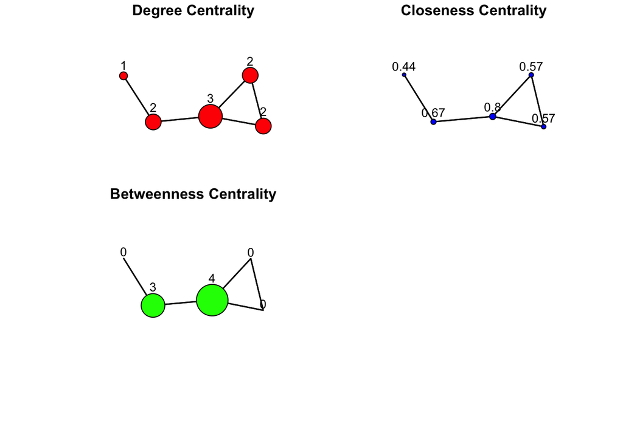

```r
par(mfrow = c(2,2), oma = c(5,4,0,0) + 0.1, mar = c(0,0,1,1) + 0.1)
set.seed(1)
gplot(u.mat, gmode="graph", vertex.cex=degree(u.mat,gmode="graph"), label = round(degree(u.mat,gmode="graph"),2), label.pos = 3, vertex.col= "red", main="Degree Centrality")
set.seed(1)
gplot(u.mat, gmode = "graph", vertex.cex=closeness(u.mat,gmode="graph"), label = round(closeness(u.mat,gmode="graph"),2), label.pos = 3,vertex.col= "blue", main="Closeness Centrality")
set.seed(1)
gplot(u.mat, gmode = "graph", vertex.cex=betweenness(u.mat,gmode="graph"), label=round(betweenness(u.mat,gmode="graph"),2) , label.pos =3,vertex.col= "green", main="Betweenness Centrality")
par(mfrow=c(1,1)) # return plotting pane to have 1 panel.
```

### **Closeness and Betweenness Centrality for Directed Graphs**

```r
# Build the objects.
d.mat <- rbind(c(0,1,0,0,0),c(0,0,1,0,0),c(0,0,0,1,1),c(0,0,1,0,1),c(0,0,1,1,0))
rownames(d.mat) <- c("Jen","Tom","Bob","Leaf","Jim")
colnames(d.mat) <- c("Jen","Tom","Bob","Leaf","Jim")
d.net <- network(d.mat, matrix.type = "adjacency", directed = TRUE)


### Closeness Centrality.

# Manually.
distances <- geodist(d.mat)
geodesics <- distances$gdist
geodesics[geodesics == Inf] <- 0 # code Inf values as zero.
1/rowSums(geodesics) #unstandardized closeness.
```

```
## [1] 0.1111111 0.2000000 0.5000000 0.5000000 0.5000000
```

```r
(1/rowSums(geodesics))*4 #standardized closeness.
```

```
## [1] 0.4444444 0.8000000 2.0000000 2.0000000 2.0000000
```

```r
# Or, using the closeness() function.
closeness(d.mat, gmode="digraph") #standardized closeness.
```

```
## [1] 0.4444444 0.0000000 0.0000000 0.0000000 0.0000000
```

```r
closeness(d.mat, gmode="digraph")/4 #unstandardized closeness.
```

```
## [1] 0.1111111 0.0000000 0.0000000 0.0000000 0.0000000
```

```r
# Group Closeness Centralization.
centralization(d.net,closeness,mode="digraph")
```

```
## [1] 0.5555556
```

```r
centralization(d.net,closeness,mode="digraph")
```

```
## [1] 0.5555556
```

```r
### Betweenness Centrality.

# using the betweenness() function.
betweenness(d.mat,gmode="digraph") #unstandardized.
```

```
## [1] 0 3 4 0 0
```

```r
betweenness(d.mat,gmode="digraph") / (((5-1)*(5-2))/2) # standardized.
```

```
## [1] 0.0000000 0.5000000 0.6666667 0.0000000 0.0000000
```

```r
# Group Betweenness Centralization.
centralization(d.mat,betweenness,mode="digraph")
```

```
## [1] 0.2708333
```

### **Centrality in PINS Get Along With Network**

The *Prison Inmate Networks Study (PINS)* examines the social networks of prison inmates in a state correctional institution. Information about PINS can be accessed at: http://justicecenter.psu.edu/research/projects/prison-inmate-networks-study-pins.

If you scroll through the website, you will see that there are two edgelists avaiable. The *get along with network* which measures the individuals that individuals indicated they “get along with” on the unit. There is also the *power and influence network* which captures nominations made of individuals who were considered “powerful and influential” on the unit.

We can examine the centrality scores by first building the *get along with* network from the edgelist on the website:

```r
GA.edgelist <- read.csv(url("http://justicecenter.psu.edu/research/projects/files/pins-get-along-with-edgelist"),header=FALSE,as.is=TRUE)
GA.net <- as.network(GA.edgelist,directed=TRUE, matrix.type="edgelist")

# Note that the network contains 9 isolates.
length(which(has.edges(GA.net) ==FALSE))
```

```
## [1] 9
```

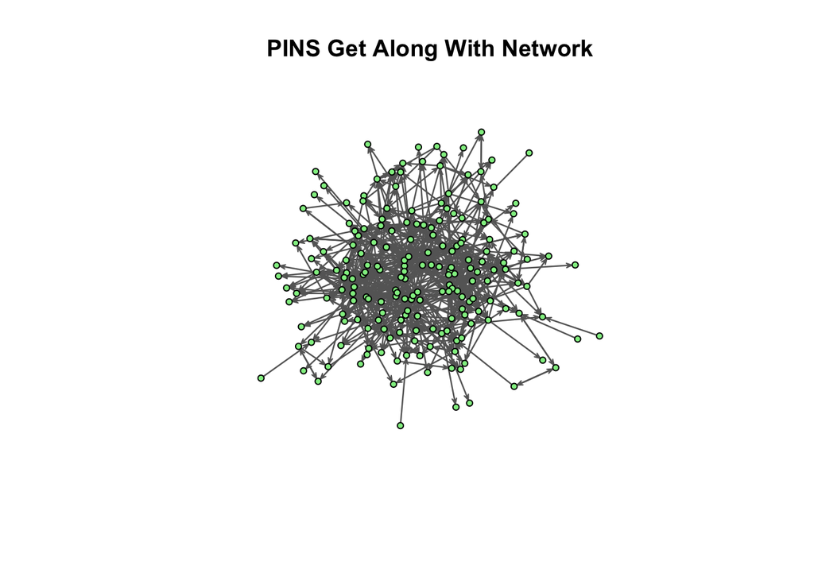

```r
# We can remove these by using the get.inducedSubgraph() function.
# Specifically, we stipulate in the v= argument that we only want vertices that have edges incident on them.
GA.net <- get.inducedSubgraph(GA.net, v=which(has.edges(GA.net) ==TRUE))

# Now, take a look at the plot.
gplot(GA.net, edge.col="grey40", vertex.col="lightgreen", main="PINS Get Along With Network")
```

#### *What are the features of the network that “jump-out” when you examine the plot?*